# Math 472/572 Homework 2: Using dplyr

Graham Swain

Due Wednesday, February 9, 2022

## Instructions

You’ve been provided with the spreadsheet (.csv) on WCU employee salary data retrieved (and slightly reformmated) from UNC Salary Database https://uncdm.northcarolina.edu/salaries/index.php. The variables in this data set are institution, last_name, first_name, init (middle initial), age, job_category, annual_salary, home_dept, work_title, and hire_date (given in the form YYYYMMDD).

You are to import this into R and use R functionality to answer the following problems. Please put the answer(s) to each problem in the space immediately below the problem, and include all of the associated R code and output needed.

## Problems

1. Add three new variables to this data frame: `hr_yr`, `hr_mo`, `hr_day` where they are the year, month, and day of the hire. Then add another new variable, `yrs_here`, giving the number of years the person has been at WCU (make this simple and determine this to be 2022 minus their hire year). Make sure you save this data frame to a name (the name of the original data frame, or a new name).

```r
salary <- mutate(salary, hr_yr = hire_date %/% 10000,
                 hr_month = (hire_date %% 10000) %/% 100 ,
                 hr_day = hire_date %% 100,
                 yrs_here = 2022 - hr_yr)
salary %>% head(5)
```

```
##   institution last_name first_name init age               job_category
## 1         WCU     Abiah   Jeremiah    H  45        Assistant Professor
## 2         WCU     Abram      Susan    M  68                 Instructor
## 3         WCU     Adams     Andrew    D  58 Assoc/Asst Dean, Fine Arts
## 4         WCU     Adams       Erin    E  47                  Professor
## 5         WCU     Adams       Mary <NA>  60        Associate Professor
##   annual_salary                           home_dept
## 1         65000            School of Stage & Screen
## 2         45000                             History
## 3        104015 Office, Dean, Fine & Performing Art
## 4         69331              School of Art & Design
## 5         68834                             English
##                       work_title hire_date hr_yr hr_month hr_day yrs_here
## 1            Assistant Professor  20210801  2021        8      1        1
## 2                     Instructor  20180801  2018        8      1        4
## 3 Interim Director SON/Professor  20060815  2006        8     15       16
## 4                      Professor  20080801  2008        8      1       14
## 5            Associate Professor  19950801  1995        8      1       27
```

2. Return a data frame containing only information for Associate Professors in English. Next return a data frame containing home departments and job title pairings (e.g. History, Instructor; History, Assistant Professor; …) along with the mean salary, median age, and standard deviation of years here.

```r
(salary_eng <- salary %>% filter(home_dept == "English",
                      work_title == "Associate Professor")) %>%
  head(5)
```

```
##   institution last_name first_name init age        job_category annual_salary
## 1         WCU     Adams       Mary <NA>  60 Associate Professor         68834
## 2         WCU Boatright    Michael    D  47 Associate Professor         65455
## 3         WCU  Callahan       Erin    E  44 Associate Professor         64926
## 4         WCU    Duncan     Pamela    Y  60 Associate Professor         64506
## 5         WCU     Huber       Beth <NA>  58 Associate Professor         64506
##   home_dept          work_title hire_date hr_yr hr_month hr_day yrs_here
## 1   English Associate Professor  19950801  1995        8      1       27
## 2   English Associate Professor  20120801  2012        8      1       10
## 3   English Associate Professor  20130801  2013        8      1        9
## 4   English Associate Professor  20080730  2008        7     30       14
## 5   English Associate Professor  20040801  2004        8      1       18
```

```r
dept_stats <- (salary %>%
                 group_by(home_dept, work_title) %>%
                 summarize(mean_salary = mean(annual_salary, na.rm = TRUE),
                           med_age = median(age, na.rm = TRUE),
                           std_years = sd(yrs_here, na.rm = TRUE)))
dept_stats %>% head(5)
```

```
## # A tibble: 5 × 5
## # Groups:   home_dept [1]
##   home_dept                           work_title   mean_salary med_age std_years
##   <chr>                               <chr>              <dbl>   <dbl>     <dbl>
## 1 Academic Engagement & IT Governance Acad Proces…       78000      56        NA
## 2 Academic Engagement & IT Governance Assoc CIO/D…      120000      58        NA
## 3 Academic Engagement & IT Governance Bus/Tech Ap…       85680      47        NA
## 4 Academic Engagement & IT Governance Chief Purch…       83537      60        NA
## 5 Academic Engagement & IT Governance IT Business…       73408      54        NA
```

3. What is the total amount of money spent on professor salaries (assistant professor, associate professor, and professor) in the Mathematics & Computer Science Department.

```r
cs <- filter(salary, home_dept == "Mathematics & Computer Science" &
         (job_category == "Assistant Professor" |
         job_category == "Associate Professor" |
         job_category == "Professor"))
(cs %>% group_by(job_category) %>% summarize(total_salary = sum(annual_salary)))
```

```
## # A tibble: 3 × 2
##   job_category        total_salary
##   <chr>                      <int>
## 1 Assistant Professor       196146
## 2 Associate Professor       616841
## 3 Professor                 522015
```

```r
sum(cs$annual_salary)
```

```
## [1] 1335002
```

**Assistant Professors: $196,146**  
**Associate Professors: $616,841**  
**Professors: $522,015**  
**Total Professor Salaries: $1,335,002**

4. Create a data frame called `psyc` whose rows are the employees from the Psychology department and includes only the variables last_name, first_name, annual_salary, work_title, and hr_yr and is ordered by annual salary (from highest pay to lowest pay). Next, make a box plot of the annual salary broken out by work title.

```r
psyc <- (salary %>%
           filter(home_dept == "Psychology") %>%
           select(last_name, first_name, annual_salary, work_title, hr_yr) %>%
           arrange(desc(annual_salary)))
psyc %>% head(5)
```

```
##   last_name first_name annual_salary          work_title hr_yr
## 1  Campbell   Jonathan        116000           Professor  2018
## 2    McCord      David         89212           Professor  1989
## 3      Ford     Thomas         78885           Professor  2007
## 4    Sigler      Ellen         78209 Associate Professor  2009
## 5      Roth     Nathan         78001 Associate Professor  2015
```

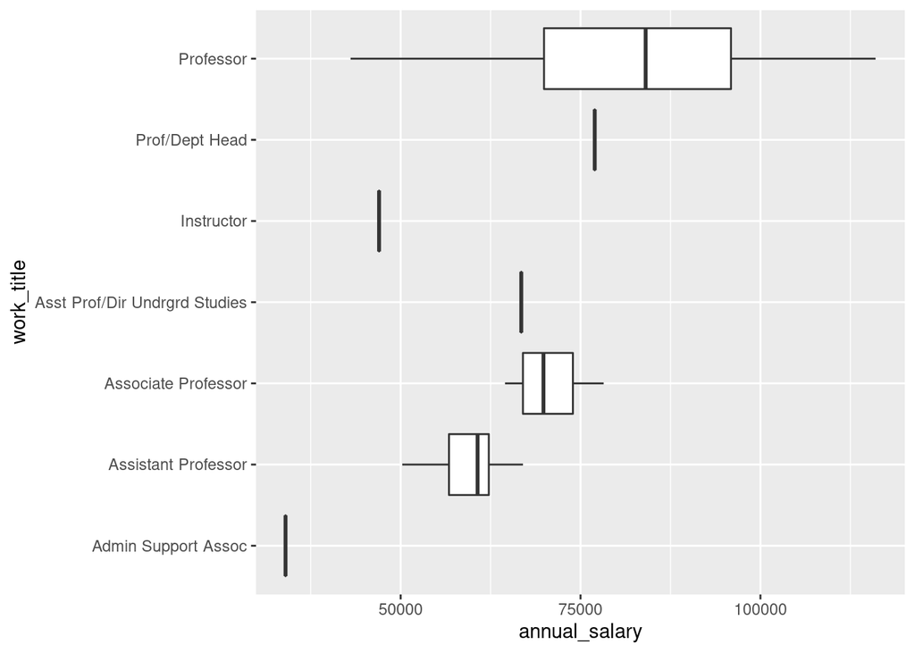

```r
ggplot(psyc) +
  geom_boxplot(aes(x = annual_salary, y = work_title))
```

5. Use faceting (recall from `ggplot()`) to make histograms of annual salaries of the Biology, Chemistry & Physics, Geosciences & Natural Resources, and Mathematics & Computer Science departments. Next use faceting to make a plot of age versus annual salaries for these same departments, using work_title to determine the color and size of the points.

```r
salary5 <- (salary %>%
              filter(home_dept == "Biology" |
                       home_dept == "Chemistry & Physics" |
                       home_dept == "Geosciences & Natural Resources" |
                       home_dept == "Mathematics & Computer Science"))
salary5 %>% head(5)
```

```
##   institution last_name first_name init age             job_category
## 1         WCU   Adkison    Gregory    P  56               Instructor
## 2         WCU    Aldeni    Mahmoud <NA>  35      Assistant Professor
## 3         WCU   Ashmore     Joseph    M  34 Administrative Assistant
## 4         WCU  Atanasov      Risto <NA>  51                Professor
## 5         WCU Atterholt    Cynthia    A  66      Associate Professor
##   annual_salary                      home_dept          work_title hire_date
## 1         53840                        Biology     Visit Asst Prof  20020815
## 2         63000 Mathematics & Computer Science Assistant Professor  20190801
## 3         34500 Mathematics & Computer Science Admin Support Assoc  20211115
## 4         98928 Mathematics & Computer Science           Professor  20070801
## 5         40665            Chemistry & Physics Associate Professor  19960801
##   hr_yr hr_month hr_day yrs_here
## 1  2002        8     15       20
## 2  2019        8      1        3
## 3  2021       11     15        1
## 4  2007        8      1       15
## 5  1996        8      1       26
```

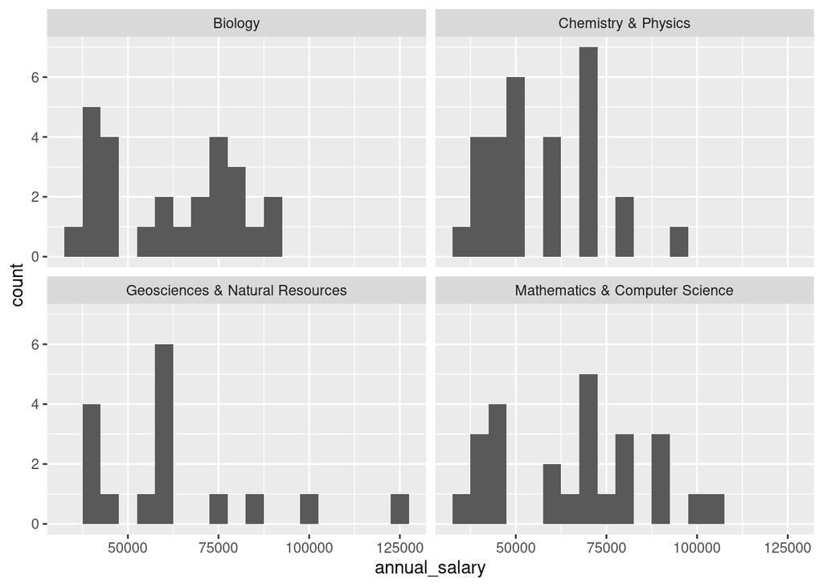

```r
ggplot(salary5) +
  geom_histogram(aes(x = annual_salary), binwidth = 5000) +
  facet_wrap(~home_dept)
```

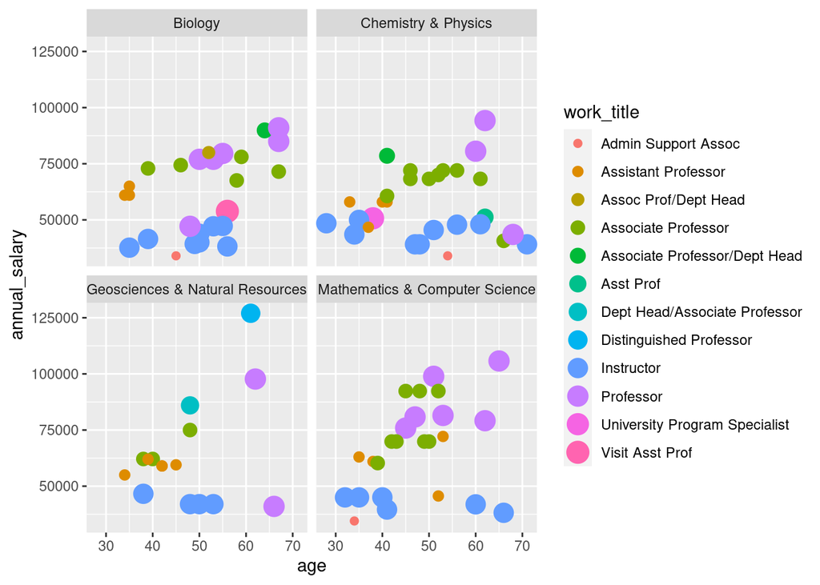

```r
ggplot(salary5) +
  geom_point(aes(x = age, y = annual_salary, color = work_title, size = work_title)) +
  facet_wrap(~home_dept)
```

6. Create a data frame called `dept_summary` whose rows are the home departments and whose columns are department size, mean department salary, median department salary, and maximum salary. Then order the departments by the highest mean salary and show the 10 highest paid departments. Lastly, order the departments by the highest median salary and show the 10 highest paid departments.

```r
dept_summary <- (salary %>%
                   group_by(home_dept) %>%
                   summarize(dept_size = n(),
                             mean_salary = mean(annual_salary, na.rm = TRUE),
                             med_salary = median(annual_salary, na.rm = TRUE),
                             max_salary = max(annual_salary)))
dept_summary %>% head(5)
```

```
## # A tibble: 5 × 5
##   home_dept                          dept_size mean_salary med_salary max_salary
##   <chr>                                  <int>       <dbl>      <dbl>      <int>
## 1 Academic Engagement & IT Governan…         6      88421.     84608.     120000
## 2 Access Services                            7      46087      40332       90000
## 3 Acct, Fin, Info Sys, Bus Law              28     104603.    116530      143000
## 4 Admissions                                19      47938.     37500      110247
## 5 Advancement Services                       6      55157.     61224       68000
```

```r
(dept_summary %>% arrange(desc(mean_salary)) %>% head(10))
```

```
## # A tibble: 10 × 5
##    home_dept                         dept_size mean_salary med_salary max_salary
##    <chr>                                 <int>       <dbl>      <dbl>      <int>
##  1 Office of the VC, Admin & Finance         1     240952     240952      240952
##  2 Office, Associate VC, Fiscal Aff…         1     140000     140000      140000
##  3 Office of the VC, Student Affairs         2     133134.    133134.     203384
##  4 Assoc VC Student Success                  1     130354     130354      130354
##  5 Office Equal Opport Diversity Pr…         1     117725     117725      117725
##  6 Office of the Provost                     7     113460.     87966      250000
##  7 Office, Assoc VC Student Affairs          1     110000     110000      110000
##  8 Office, Asst VC, Student Affairs…         1     109821     109821      109821
##  9 Legal Counsel & Technology Trans…         5     107607.    108000      180560
## 10 Econ, Mgt, Proj Mgt                      23     104863.    104990      172056
```

```r
(dept_summary %>% arrange(desc(med_salary)) %>% head(10))
```

```
## # A tibble: 10 × 5
##    home_dept                         dept_size mean_salary med_salary max_salary
##    <chr>                                 <int>       <dbl>      <dbl>      <int>
##  1 Office of the VC, Admin & Finance         1     240952     240952      240952
##  2 Office, Associate VC, Fiscal Aff…         1     140000     140000      140000
##  3 Office of the VC, Student Affairs         2     133134.    133134.     203384
##  4 Assoc VC Student Success                  1     130354     130354      130354
##  5 Office Equal Opport Diversity Pr…         1     117725     117725      117725
##  6 Acct, Fin, Info Sys, Bus Law             28     104603.    116530      143000
##  7 Office, Assoc VC Student Affairs          1     110000     110000      110000
##  8 Office, Asst VC, Student Affairs…         1     109821     109821      109821
##  9 Legal Counsel & Technology Trans…         5     107607.    108000      180560
## 10 Econ, Mgt, Proj Mgt                      23     104863.    104990      172056
```

7. What year(s) saw the greatest number of hires of current WCU employees? Indicate the distribution of employees hired over time, in some visual display.

```r
years <- (salary %>%
            group_by(hr_yr) %>%
            summarize(count = n()) %>%
            arrange(desc(count)))
years  %>% head(5)
```

```
## # A tibble: 5 × 2
##   hr_yr count
##   <dbl> <int>
## 1  2019   148
## 2  2021   143
## 3  2016   110
## 4  2018    99
## 5  2017    89
```

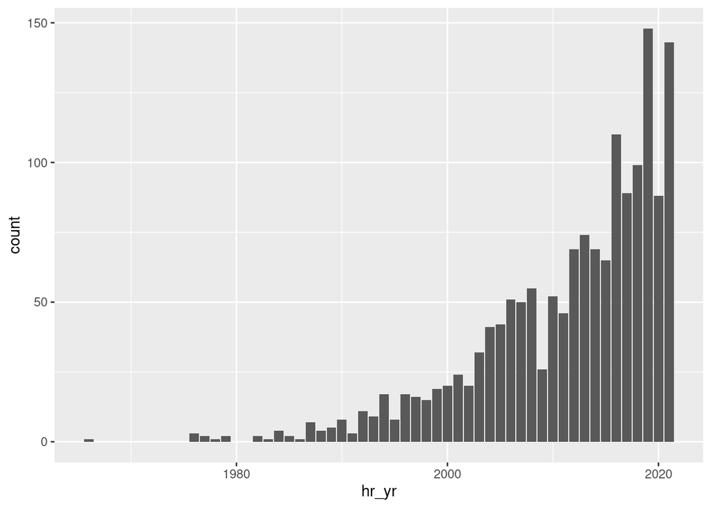

```r
ggplot(years) +
  geom_col(aes(x = hr_yr, y = count))
```

**2019 had the most hires**